# **Unsupervised Learning: Trade & Ahead**

# Problem Statement

### Context

The stock market has consistently proven to be a good place to invest in and save for the future. There are a lot of compelling reasons to invest in stocks. It can help in fighting inflation, create wealth, and also provides some tax benefits. Good steady returns on investments over a long period of time can also grow a lot more than seems possible. Also, thanks to the power of compound interest, the earlier one starts investing, the larger the corpus one can have for retirement. Overall, investing in stocks can help meet life's financial aspirations.

It is important to maintain a diversified portfolio when investing in stocks in order to maximise earnings under any market condition. Having a diversified portfolio tends to yield higher returns and face lower risk by tempering potential losses when the market is down. It is often easy to get lost in a sea of financial metrics to analyze while determining the worth of a stock, and doing the same for a multitude of stocks to identify the right picks for an individual can be a tedious task. By doing a cluster analysis, one can identify stocks that exhibit similar characteristics and ones which exhibit minimum correlation. This will help investors better analyze stocks across different market segments and help protect against risks that could make the portfolio vulnerable to losses.

### Objective

Trade&Ahead is a financial consultancy firm who provide their customers with personalized investment strategies. They have hired you as a Data Scientist and provided you with data comprising stock price and some financial indicators for a few companies listed under the New York Stock Exchange. They have assigned you the tasks of analyzing the data, grouping the stocks based on the attributes provided, and sharing insights about the characteristics of each group.

### Data Dictionary

- Ticker Symbol: An abbreviation used to uniquely identify publicly traded shares of a particular stock on a particular stock market
- Security: Name of the company
- GICS Sector: The specific economic sector assigned to a company by the Global Industry Classification Standard (GICS) that best defines its business operations
- GICS Sub Industry: The specific sub-industry group assigned to a company by the Global Industry Classification Standard (GICS) that best defines its business operations
- Current Price: Current stock price in dollars
- Price Change: Percentage change in the stock price in 13 weeks
- Volatility: Standard deviation of the stock price over the past 13 weeks
- ROE: A measure of financial performance calculated by dividing net income by shareholders' equity (shareholders' equity is equal to a company's assets minus its debt)
- Cash Ratio: The ratio of a company's total reserves of cash and cash equivalents to its total current liabilities
- Net Cash Flow: The difference between a company's cash inflows and outflows (in dollars)
- Net Income: Revenues minus expenses, interest, and taxes (in dollars)
- Earnings Per Share: Company's net profit divided by the number of common shares it has outstanding (in dollars)
- Estimated Shares Outstanding: Company's stock currently held by all its shareholders
- P/E Ratio: Ratio of the company's current stock price to the earnings per share
- P/B Ratio: Ratio of the company's stock price per share by its book value per share (book value of a company is the net difference between that company's total assets and total liabilities)

# Importing necessary libraries and data

```python
# Libraries to help with reading and manipulating data
import numpy as np
import pandas as pd

# Libraries to help with data visualization
import math
import matplotlib.pyplot as plt
import seaborn as sns

# Removes the limit for the number of displayed columns
pd.set_option("display.max_columns", None)
# Sets the limit for the number of displayed rows
pd.set_option("display.max_rows", 200)

# to split the data
from sklearn.model_selection import train_test_split

# to scale the data using z-score
from scipy.stats import zscore
from sklearn.preprocessing import StandardScaler

# to compute distances
from scipy.spatial.distance import cdist, pdist

# to perform hierarchical clustering, compute cophenetic correlation, and create dendrograms
from sklearn.cluster import AgglomerativeClustering
from scipy.cluster.hierarchy import dendrogram, linkage, cophenet, fcluster

# to perform PCA
from sklearn.decomposition import PCA

# to perform k-means clustering and compute silhouette scores
from sklearn.cluster import KMeans
from sklearn.metrics import silhouette_score

# to visualize the elbow curve and silhouette scores
from yellowbrick.cluster import KElbowVisualizer, SilhouetteVisualizer
```

# Reading the Dataset

```python
# Import data files
from google.colab import drive
drive.mount('/content/drive')

df_path = "/content/drive/MyDrive/DS Course/stock_data.csv"
df = pd.read_csv(df_path)

# Make a copy of the data to ease troubleshooting
data = df.copy()
```

# Data Overview

- Observations
- Sanity checks

```python
# Check the shape of the dataset
print(data.shape)
```

```
(340, 15)
```

```python
# Display a few rows to get a feel for the data
data.sample(n=10, random_state=1)
```

|  | Ticker Symbol | Security | GICS Sector | GICS Sub Industry | Current Price | Price Change | Volatility | ROE | Cash Ratio | Net Cash Flow | Net Income | Earnings Per Share | Estimated Shares Outstanding | P/E Ratio | P/B Ratio |
| --- | --- | --- | --- | --- | --- | --- | --- | --- | --- | --- | --- | --- | --- | --- | --- |
| 102 | DVN | Devon Energy Corp. | Energy | Oil & Gas Exploration & Production | 32.000000 | -15.478079 | 2.923698 | 205 | 70 | 830000000 | -14454000000 | -35.55 | 4.065823e+08 | 93.089287 | 1.785616 |
| 125 | FB | Facebook | Information Technology | Internet Software & Services | 104.660004 | 16.224320 | 1.320606 | 8 | 958 | 592000000 | 3669000000 | 1.31 | 2.800763e+09 | 79.893133 | 5.884467 |
| 11 | AIV | Apartment Investment & Mgmt | Real Estate | REITs | 40.029999 | 7.578608 | 1.163334 | 15 | 47 | 21818000 | 248710000 | 1.52 | 1.636250e+08 | 26.335526 | -1.269332 |
| 248 | PG | Procter & Gamble | Consumer Staples | Personal Products | 79.410004 | 10.660538 | 0.806056 | 17 | 129 | 160383000 | 636056000 | 3.28 | 4.913916e+08 | 24.070121 | -2.256747 |
| 238 | OXY | Occidental Petroleum | Energy | Oil & Gas Exploration & Production | 67.610001 | 0.865287 | 1.589520 | 32 | 64 | -588000000 | -7829000000 | -10.23 | 7.652981e+08 | 93.089287 | 3.345102 |
| 336 | YUM | Yum! Brands Inc | Consumer Discretionary | Restaurants | 52.516175 | -8.698917 | 1.478877 | 142 | 27 | 159000000 | 1293000000 | 2.97 | 4.353535e+08 | 17.682214 | -3.838260 |
| 112 | EQT | EQT Corporation | Energy | Oil & Gas Exploration & Production | 52.130001 | -21.253771 | 2.364883 | 2 | 201 | 523803000 | 85171000 | 0.56 | 1.520911e+08 | 93.089287 | 9.567952 |
| 147 | HAL | Halliburton Co. | Energy | Oil & Gas Equipment & Services | 34.040001 | -5.101751 | 1.966062 | 4 | 189 | 7786000000 | -671000000 | -0.79 | 8.493671e+08 | 93.089287 | 17.345857 |
| 89 | DFS | Discover Financial Services | Financials | Consumer Finance | 53.619999 | 3.653584 | 1.159897 | 20 | 99 | 2288000000 | 2297000000 | 5.14 | 4.468872e+08 | 10.431906 | -0.375934 |
| 173 | IVZ | Invesco Ltd. | Financials | Asset Management & Custody Banks | 33.480000 | 7.067477 | 1.580839 | 12 | 67 | 412000000 | 968100000 | 2.26 | 4.283628e+08 | 14.814159 | 4.218620 |

```python
# Check the data types to see what other columns might need pre-processing
data.info()
```

```
<class 'pandas.core.frame.DataFrame'>
RangeIndex: 340 entries, 0 to 339
Data columns (total 15 columns):
 #   Column                        Non-Null Count  Dtype
---  ------                        --------------  -----
 0   Ticker Symbol                 340 non-null    object
 1   Security                      340 non-null    object
 2   GICS Sector                   340 non-null    object
 3   GICS Sub Industry             340 non-null    object
 4   Current Price                 340 non-null    float64
 5   Price Change                  340 non-null    float64
 6   Volatility                    340 non-null    float64
 7   ROE                           340 non-null    int64
 8   Cash Ratio                    340 non-null    int64
 9   Net Cash Flow                 340 non-null    int64
 10  Net Income                    340 non-null    int64
 11  Earnings Per Share            340 non-null    float64
 12  Estimated Shares Outstanding  340 non-null    float64
 13  P/E Ratio                     340 non-null    float64
 14  P/B Ratio                     340 non-null    float64
dtypes: float64(7), int64(4), object(4)
memory usage: 40.0+ KB
```

```python
# Check the statistical summary of the data
data.describe(include="all").T
```

|  | count | unique | top | freq | mean | std | min | 25% | 50% | 75% | max |
| --- | --- | --- | --- | --- | --- | --- | --- | --- | --- | --- | --- |
| Ticker Symbol | 340 | 340 | ZTS | 1 | NaN | NaN | NaN | NaN | NaN | NaN | NaN |
| Security | 340 | 340 | Zoetis | 1 | NaN | NaN | NaN | NaN | NaN | NaN | NaN |
| GICS Sector | 340 | 11 | Industrials | 53 | NaN | NaN | NaN | NaN | NaN | NaN | NaN |
| GICS Sub Industry | 340 | 104 | Oil & Gas Exploration & Production | 16 | NaN | NaN | NaN | NaN | NaN | NaN | NaN |
| Current Price | 340.0 | NaN | NaN | NaN | 80.862345 | 98.055086 | 4.5 | 38.555 | 59.705 | 92.880001 | 1274.949951 |
| Price Change | 340.0 | NaN | NaN | NaN | 4.078194 | 12.006338 | -47.129693 | -0.939484 | 4.819505 | 10.695493 | 55.051683 |
| Volatility | 340.0 | NaN | NaN | NaN | 1.525976 | 0.591798 | 0.733163 | 1.134878 | 1.385593 | 1.695549 | 4.580042 |
| ROE | 340.0 | NaN | NaN | NaN | 39.597059 | 96.547538 | 1.0 | 9.75 | 15.0 | 27.0 | 917.0 |
| Cash Ratio | 340.0 | NaN | NaN | NaN | 70.023529 | 90.421331 | 0.0 | 18.0 | 47.0 | 99.0 | 958.0 |
| Net Cash Flow | 340.0 | NaN | NaN | NaN | 55537620.588235 | 1946365312.175789 | -11208000000.0 | -193906500.0 | 2098000.0 | 169810750.0 | 20764000000.0 |
| Net Income | 340.0 | NaN | NaN | NaN | 1494384602.941176 | 3940150279.327937 | -23528000000.0 | 352301250.0 | 707336000.0 | 1899000000.0 | 24442000000.0 |
| Earnings Per Share | 340.0 | NaN | NaN | NaN | 2.776662 | 6.587779 | -61.2 | 1.5575 | 2.895 | 4.62 | 50.09 |
| Estimated Shares Outstanding | 340.0 | NaN | NaN | NaN | 577028337.75403 | 845849595.417695 | 27672156.86 | 158848216.1 | 309675137.8 | 573117457.325 | 6159292035.0 |
| P/E Ratio | 340.0 | NaN | NaN | NaN | 32.612563 | 44.348731 | 2.935451 | 15.044653 | 20.819876 | 31.764755 | 528.039074 |
| P/B Ratio | 340.0 | NaN | NaN | NaN | -1.718249 | 13.966912 | -76.119077 | -4.352056 | -1.06717 | 3.917066 | 129.064585 |

```python
# Check for missing values
print(f"Missing values: \n{data.isna().sum()}")

# Check for duplicate rows in the DataFrame
duplicate_rows = data[data.duplicated()]

# Print how many duplicates were found
print(f"\nNumber of duplicate rows: {duplicate_rows.shape[0]}")
```

```
Missing values:
Ticker Symbol                   0
Security                        0
GICS Sector                     0
GICS Sub Industry               0
Current Price                   0
Price Change                    0
Volatility                      0
ROE                             0
Cash Ratio                      0
Net Cash Flow                   0
Net Income                      0
Earnings Per Share              0
Estimated Shares Outstanding    0
P/E Ratio                       0
P/B Ratio                       0
dtype: int64

Number of duplicate rows: 0
```

```python
# Check unique values to see if data cleansing is needed
cols = df.columns

for col in cols:
    print("Unique values in the column '{}' are \n\n".format(col), df[col].unique())
    print("-" * 100)
```

```
Unique values in the column 'Ticker Symbol' are

 ['AAL' 'ABBV' 'ABT' 'ADBE' 'ADI' 'ADM' 'ADS' 'AEE' 'AEP' 'AFL' 'AIG' 'AIV'
 'AIZ' 'AJG' 'AKAM' 'ALB' 'ALK' 'ALL' 'ALLE' 'ALXN' 'AMAT' 'AME' 'AMG'
 'AMGN' 'AMP' 'AMT' 'AMZN' 'AN' 'ANTM' 'AON' 'APA' 'APC' 'APH' 'ARNC'
 'ATVI' 'AVB' 'AVGO' 'AWK' 'AXP' 'BA' 'BAC' 'BAX' 'BBT' 'BCR' 'BHI' 'BIIB'
 'BK' 'BLL' 'BMY' 'BSX' 'BWA' 'BXP' 'C' 'CAT' 'CB' 'CBG' 'CCI' 'CCL'
 'CELG' 'CF' 'CFG' 'CHD' 'CHK' 'CHRW' 'CHTR' 'CI' 'CINF' 'CL' 'CMA' 'CME'
 'CMG' 'CMI' 'CMS' 'CNC' 'CNP' 'COF' 'COG' 'COO' 'CSX' 'CTL' 'CTSH' 'CTXS'
 'CVS' 'CVX' 'CXO' 'D' 'DAL' 'DD' 'DE' 'DFS' 'DGX' 'DHR' 'DIS' 'DISCA'
 'DISCK' 'DLPH' 'DLR' 'DNB' 'DOV' 'DPS' 'DUK' 'DVA' 'DVN' 'EBAY' 'ECL'
 'ED' 'EFX' 'EIX' 'EMN' 'EOG' 'EQIX' 'EQR' 'EQT' 'ES' 'ESS' 'ETFC' 'ETN'
 'ETR' 'EW' 'EXC' 'EXPD' 'EXPE' 'EXR' 'F' 'FAST' 'FB' 'FBHS' 'FCX' 'FE'
 'FIS' 'FISV' 'FLIR' 'FLR' 'FLS' 'FMC' 'FRT' 'FSLR' 'FTR' 'GD' 'GGP'
 'GILD' 'GLW' 'GM' 'GPC' 'GRMN' 'GT' 'GWW' 'HAL' 'HAS' 'HBAN' 'HCA' 'HCN'
 'HCP' 'HES' 'HIG' 'HOG' 'HON' 'HPE' 'HPQ' 'HRL' 'HSIC' 'HST' 'HSY' 'HUM'
 'IBM' 'IDXX' 'IFF' 'INTC' 'IP' 'IPG' 'IRM' 'ISRG' 'ITW' 'IVZ' 'JBHT'
 'JEC' 'JNPR' 'JPM' 'KIM' 'KMB' 'KMI' 'KO' 'KSU' 'LEG' 'LEN' 'LH' 'LKQ'
 'LLL' 'LLY' 'LMT' 'LNT' 'LUK' 'LUV' 'LVLT' 'LYB' 'MA' 'MAA' 'MAC' 'MAR'
 'MAS' 'MAT' 'MCD' 'MCO' 'MDLZ' 'MET' 'MHK' 'MJN' 'MKC' 'MLM' 'MMC' 'MMM'
 'MNST' 'MO' 'MOS' 'MPC' 'MRK' 'MRO' 'MTB' 'MTD' 'MUR' 'MYL' 'NAVI' 'NBL'
 'NDAQ' 'NEE' 'NEM' 'NFLX' 'NFX' 'NLSN' 'NOV' 'NSC' 'NTRS' 'NUE' 'NWL' 'O'
 'OKE' 'OMC' 'ORLY' 'OXY' 'PBCT' 'PBI' 'PCAR' 'PCG' 'PCLN' 'PEG' 'PEP'
 'PFE' 'PFG' 'PG' 'PGR' 'PHM' 'PM' 'PNC' 'PNR' 'PNW' 'PPG' 'PPL' 'PRU'
 'PSX' 'PWR' 'PX' 'PYPL' 'R' 'RCL' 'REGN' 'RHI' 'ROP' 'RRC' 'RSG' 'SCG'
 'SCHW' 'SE' 'SEE' 'SHW' 'SLG' 'SNI' 'SO' 'SPG' 'SPGI' 'SRCL' 'SRE' 'STI'
 'STT' 'SWKS' 'SWN' 'SYF' 'SYK' 'T' 'TAP' 'TDC' 'TGNA' 'TMK' 'TMO' 'TRIP'
 'TRV' 'TSCO' 'TSN' 'TSO' 'TSS' 'TXN' 'UAA' 'UAL' 'UDR' 'UHS' 'UNH' 'UNM'
 'UNP' 'UPS' 'UTX' 'VAR' 'VLO' 'VMC' 'VNO' 'VRSK' 'VRSN' 'VRTX' 'VTR' 'VZ'
 'WAT' 'WEC' 'WFC' 'WHR' 'WM' 'WMB' 'WU' 'WY' 'WYN' 'WYNN' 'XEC' 'XEL'
 'XL' 'XOM' 'XRAY' 'XRX' 'XYL' 'YHOO' 'YUM' 'ZBH' 'ZION' 'ZTS']
----------------------------------------------------------------------------------------------------
Unique values in the column 'Security' are

 ['American Airlines Group' 'AbbVie' 'Abbott Laboratories'
 'Adobe Systems Inc' 'Analog Devices, Inc.' 'Archer-Daniels-Midland Co'
 'Alliance Data Systems' 'Ameren Corp' 'American Electric Power'
 'AFLAC Inc' 'American International Group, Inc.'
 'Apartment Investment & Mgmt' 'Assurant Inc' 'Arthur J. Gallagher & Co.'
 'Akamai Technologies Inc' 'Albemarle Corp' 'Alaska Air Group Inc'
```

[output cut: 772 more lines]

[output not shown]

### Data Observations

**Data Types**

- The data types appear appropriate overall: numerical columns are typed as `float64` or `int64`, and categorical identifiers are `object`.
- The columns `Ticker Symbol` and `Security` were dropped, while `GICS Sector`, and `GICS Sub Industry` were converted to `category` dtype for efficiency and clarity.

**Missing or Placeholder Values**

- All columns show 340 non-null values, indicating there are no missing values in the dataset.
- The data appears to be relatively clean and without duplicates.

**Categorical Encoding**

- The object-type columns will need to be encoded before modeling.
- Encoding of `GICS Sub Industry` will be tricky as it contains many unique values.

**Outlier Detection**

- Extremely high or low values in `ROE`, `Cash Ratio`, and `EPS` suggest outliers.
- Outlier detection methods such as IQR, z-score, or visualizations like boxplots should be used to assess their impact.

**Feature Scaling**

- Numerical features such as `Current Price`, `Volatility`, `ROE`, and `Cash Ratio` vary significantly in scale.
- We will want to apply standardization or normalization.

**Feature Engineering**

- Additional features could be derived, such as:
  - `Market Cap = Current Price × Estimated Shares Outstanding`
  - `Earnings Yield = EPS / Current Price`
- These may add predictive value, especially in financial modeling.

# Exploratory Data Analysis (EDA)

### Problem Statement

The goal of this project is to analyze financial and stock market data from 340 publicly traded companies to identify meaningful patterns and similarities among them. The dataset contains a mix of valuation metrics (e.g., P/E Ratio, P/B Ratio), performance indicators (e.g., ROE, Net Income, EPS), and liquidity measures (e.g., Cash Ratio, Net Cash Flow), along with sector classifications.

Through exploratory data analysis (EDA), we aim to:

- Understand the distribution and variability of key financial indicators
- Examine relationships between metrics and across economic sectors
- Identify and treat outliers that could impact clustering performance
- Prepare the data for unsupervised learning methods such as K-Means and Hierarchical Clustering

This analysis will ultimately support segmenting companies based on their financial profiles, with applications in investment analysis, portfolio construction, or strategic benchmarking.

### Data Background

The dataset includes 340 entries representing different publicly traded companies. Each entry contains:

- Categorical attributes such as `GICS Sector` and `GICS Sub Industry`
- Financial metrics including `Current Price`, `P/E Ratio`, `Cash Ratio`, `ROE`, `EPS`, and more
- The goal is to analyze these features to identify patterns and prepare for unsupervised learning tasks like K-Means and Hierarchical Clustering.

**Questions**:

1. What does the distribution of data look like with regards to outliers?
2. What does the distribution of stock prices look like?
3. The stocks of which economic sector have seen the maximum price increase on average?
4. How are the different variables correlated with each other?
5. Cash ratio provides a measure of a company's ability to cover its short-term obligations using only cash and cash equivalents. How does the average cash ratio vary across economic sectors?
6. P/E ratios can help determine the relative value of a company's shares as they signify the amount of money an investor is willing to invest in a single share of a company per dollar of its earnings. How does the P/E ratio vary, on average, across economic sectors?

## Visualize skewness and concentration of key metrics

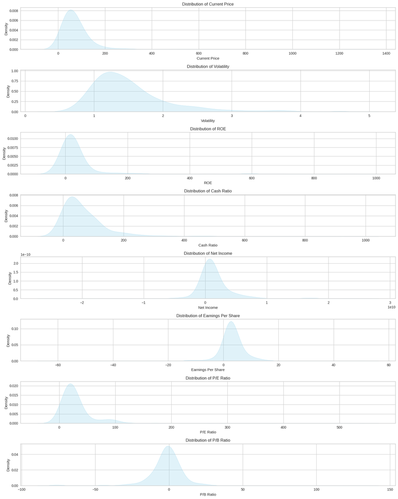

```python
# List of key financial metrics to plot
key_metrics = [
    'Current Price',
    'Volatility',
    'ROE',
    'Cash Ratio',
    'Net Income',
    'Earnings Per Share',
    'P/E Ratio',
    'P/B Ratio'
]

# Set up the figure
plt.figure(figsize=(16, len(key_metrics) * 2.5))

# Create a KDE plot for each metric
for i, col in enumerate(key_metrics, 1):
    plt.subplot(len(key_metrics), 1, i)
    sns.kdeplot(data[col], fill=True, color='skyblue')
    plt.title(f'Distribution of {col}')
    plt.xlabel(col)
    plt.ylabel('Density')

plt.tight_layout()
plt.show()
```

### Observations: KDE Plots of Key Financial Metrics

**Current Price**

- The distribution is right-skewed, with most stocks trading at lower price points.
- A long tail indicates the presence of a few high-priced stocks.

**Volatility**

- Most companies cluster around a modest volatility level, suggesting relatively stable prices.
- A secondary bump in the curve hints at a subset of higher-volatility stocks.

**ROE (Return on Equity)**

- The distribution is concentrated around lower ROE values, but with a long right tail.
- This suggests that while most companies have moderate or low returns, a few generate exceptionally high returns on equity.

**Cash Ratio**

- This variable shows a highly skewed distribution, with many companies maintaining low cash reserves relative to short-term liabilities.
- A small group of firms have extremely high cash ratios, indicating strong liquidity.

**P/B Ratio**

- The distribution is narrower but still right-skewed.
- A few companies are trading at very high multiples relative to book value, which may reflect growth expectations or overvaluation.

**Overall Insights**

- Most financial features exhibit right-skewed distributions with significant outliers.
- These patterns confirm the need for standardization and potentially log transformation before applying clustering algorithms.

## Examine relationships between metrics and across economic sectors

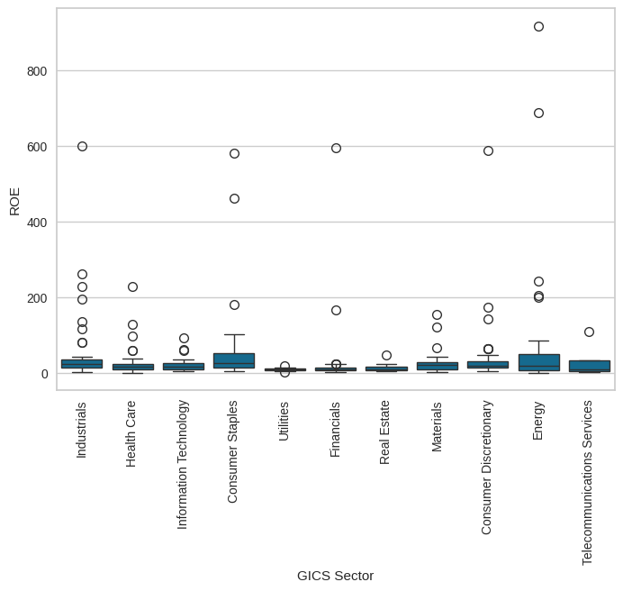

```python
sns.boxplot(x='GICS Sector', y='ROE', data=data)
plt.xticks(rotation=90)
plt.show()
```

### Observations: Boxplots of Financial Metrics by GICS Sector

**Overall Insights**

- Financial performance and valuation metrics vary substantially by sector.
- Several sectors demonstrate high internal variability (wide IQRs and many outliers), which may impact cluster formation.
- These differences support the value of including sector information during EDA, and the potential benefit of scaling or transforming skewed features before clustering.

## Outlier Visualization

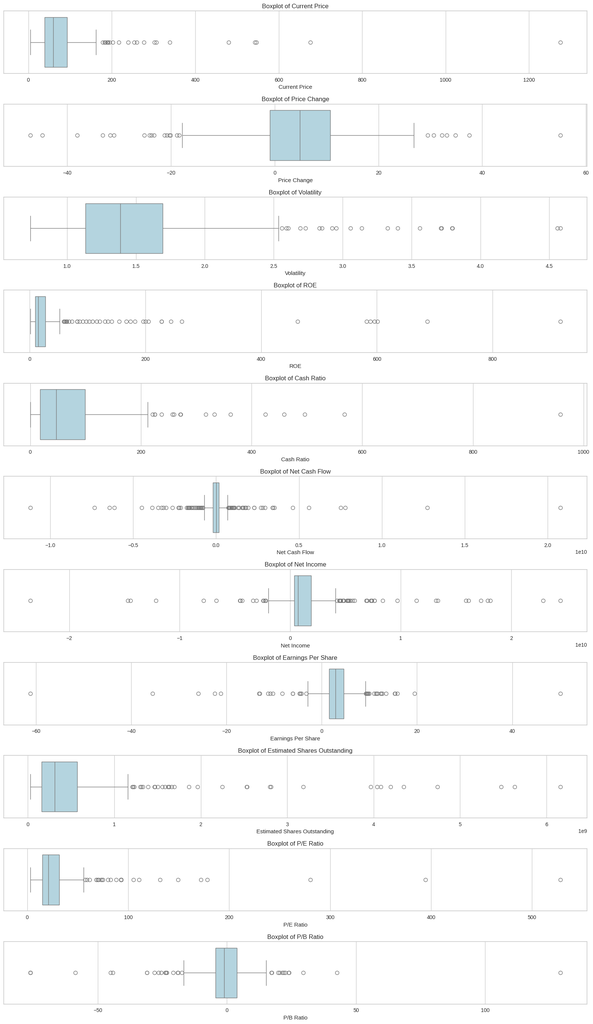

```python
# View outliers to see if they need treatment

# Select numerical columns
numeric_cols = data.select_dtypes(include=['float64', 'int64']).columns

# Plot boxplots for each numeric column
plt.figure(figsize=(16, len(numeric_cols) * 2.5))

for i, col in enumerate(numeric_cols, 1):
    plt.subplot(len(numeric_cols), 1, i)
    sns.boxplot(x=data[col], color='lightblue')
    plt.title(f'Boxplot of {col}')
    plt.xlabel(col)

plt.tight_layout()
plt.show()
```

### **Observations: Outliers**

- `Net Cash Flow` has the highest number of outliers, both above and below the expected range, suggesting extreme variability in cash operations across firms.
- `Net Income` and `Earnings Per Share` also show a high number of outliers, typically tied to profitability spikes or deep losses.
- `P/E Ratio` and `ROE` exhibit substantial upper-bound outliers, often driven by small earnings denominators or exceptional returns.
- These variables will benefit from outlier mitigation strategies to ensure they do not disproportionately influence our models.

## Pairplot of Numerical Features

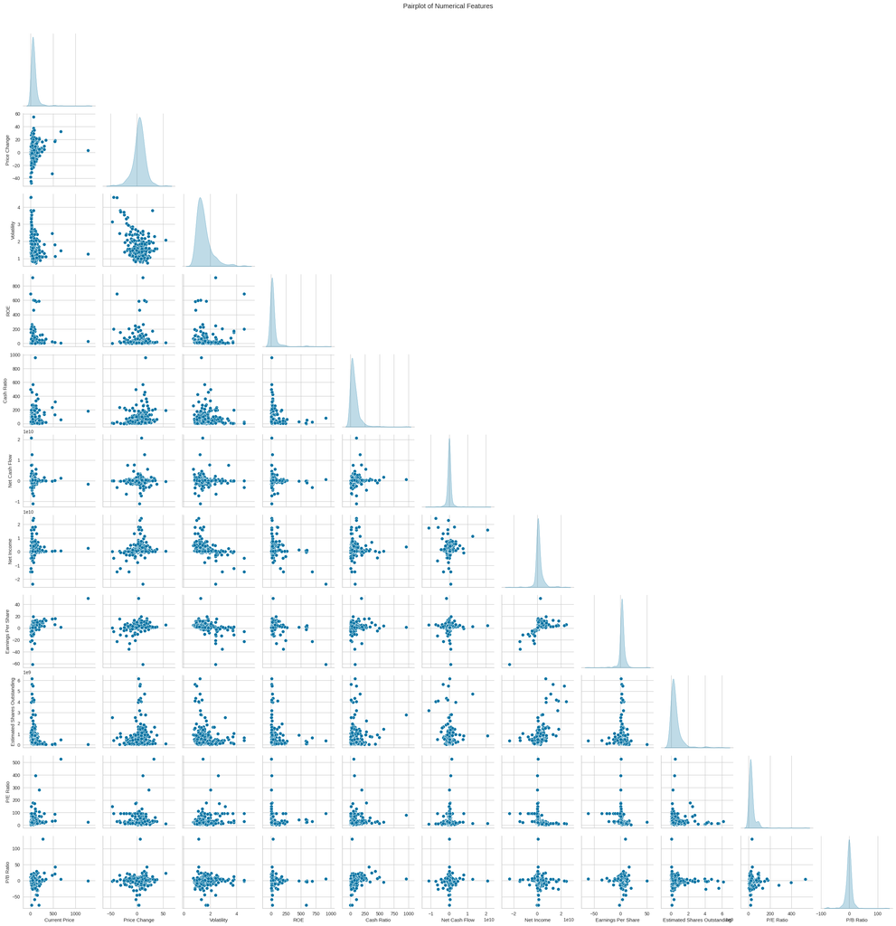

```python
# Automatically select numeric columns
numeric_cols = data.select_dtypes(include=['float64', 'int64']).columns

# Create pairplot to show us data clustering
sns.pairplot(data[numeric_cols], diag_kind='kde', corner=True)
plt.suptitle('Pairplot of Numerical Features', y=1.02)
plt.show()
```

### **Observations: Pairplot of Numerical Features**

**Distribution Patterns**

- Several variables (e.g., `P/E Ratio`, `Net Income`, `EPS`) show right-skewed distributions with long tails, suggesting the presence of extreme values or high-performing firms.
- The diagonal plots highlight that while some features (like `Current Price` and `Cash Ratio`) are concentrated around a narrow range, others like `Volatility` and `P/E Ratio` span a broad scale.

**Implications for Clustering**

- The presence of visible clumps in pairwise scatter plots (particularly in dimensions like `EPS` vs `Net Income`) suggests that clustering algorithms like K-Means or Hierarchical Clustering may identify meaningful groupings.
- Features with overlapping and diffuse distributions (like `Volatility`) may require scaling or transformation to avoid dominating distance-based metrics.

## Additional Useful Univariate and Bivariate Analysis

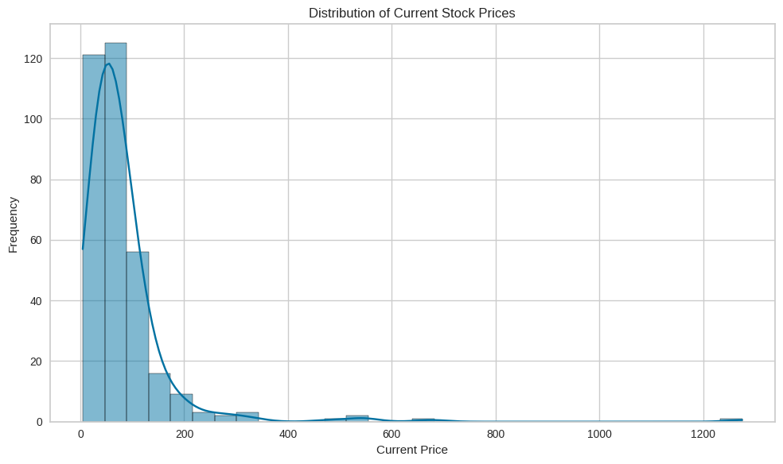

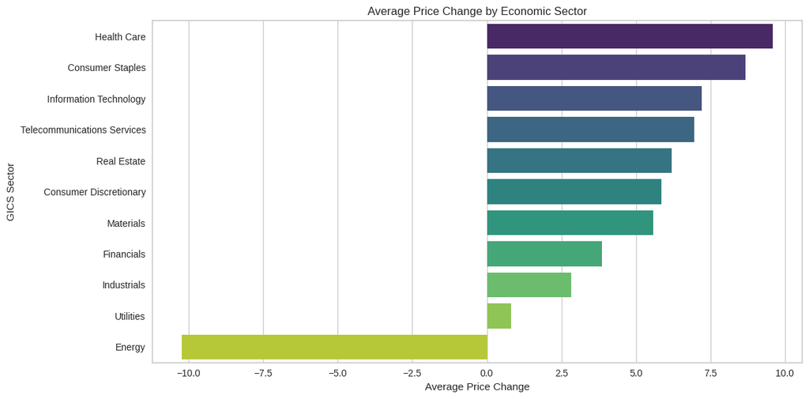

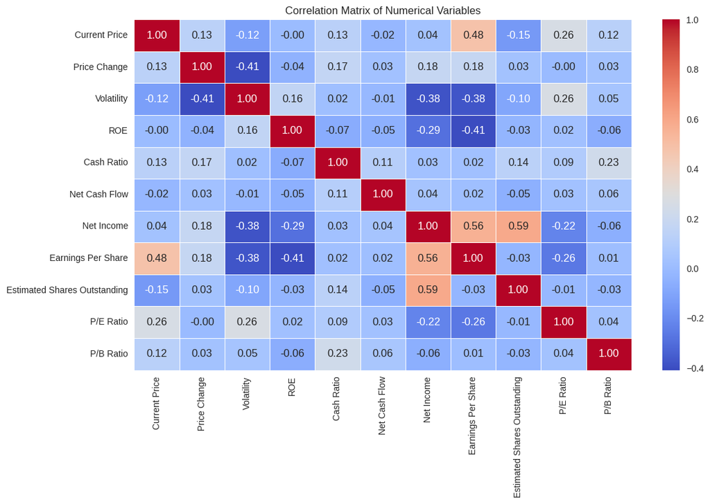

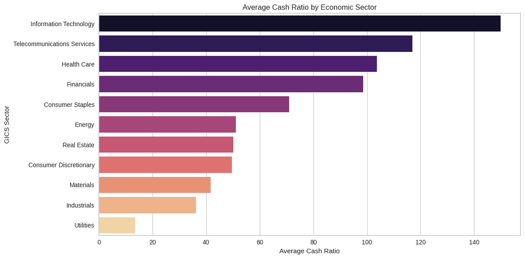

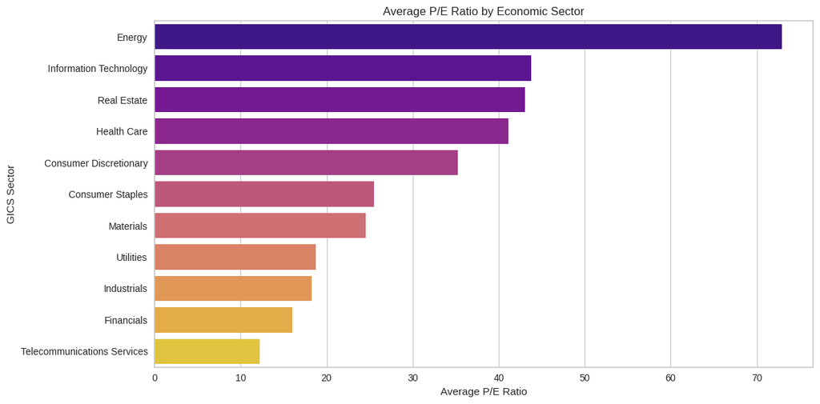

```python
# === Univariate Analysis: Distribution of Stock Prices ===
plt.figure(figsize=(10, 6))
sns.histplot(data['Current Price'], kde=True, bins=30)
plt.title('Distribution of Current Stock Prices')
plt.xlabel('Current Price')
plt.ylabel('Frequency')
plt.tight_layout()
plt.show()

# === Bivariate Analysis 1: Average Price Change by Sector ===
avg_price_change = data.groupby('GICS Sector', observed=True)['Price Change'].mean().sort_values(ascending=False)
avg_price_change_df = avg_price_change.reset_index()
avg_price_change_df.columns = ['GICS Sector', 'Average Price Change']

plt.figure(figsize=(12, 6))
sns.barplot(data=avg_price_change_df,
            x='Average Price Change',
            y='GICS Sector',
            hue='GICS Sector',
            palette='viridis',
            legend=False)
plt.title('Average Price Change by Economic Sector')
plt.xlabel('Average Price Change')
plt.ylabel('GICS Sector')
plt.tight_layout()
plt.show()

# === Bivariate Analysis 2: Correlation Matrix ===
plt.figure(figsize=(12, 8))
correlation_matrix = data.select_dtypes(include=['float64', 'int64']).corr()
sns.heatmap(correlation_matrix, annot=True, cmap='coolwarm', fmt=".2f", linewidths=0.5)
plt.title('Correlation Matrix of Numerical Variables')
plt.tight_layout()
plt.show()

# === Bivariate Analysis 3: Average Cash Ratio by Sector ===
avg_cash_ratio = data.groupby('GICS Sector', observed=True)['Cash Ratio'].mean().sort_values(ascending=False)
avg_cash_ratio_df = avg_cash_ratio.reset_index()
avg_cash_ratio_df.columns = ['GICS Sector', 'Average Cash Ratio']

plt.figure(figsize=(12, 6))
sns.barplot(data=avg_cash_ratio_df,
            x='Average Cash Ratio',
            y='GICS Sector',
            hue='GICS Sector',
            palette='magma',
            legend=False)
plt.title('Average Cash Ratio by Economic Sector')
plt.xlabel('Average Cash Ratio')
plt.ylabel('GICS Sector')
plt.tight_layout()
plt.show()

# === Bivariate Analysis 4: Average P/E Ratio by Sector ===
avg_pe_ratio = data.groupby('GICS Sector', observed=True)['P/E Ratio'].mean().sort_values(ascending=False)
avg_pe_ratio_df = avg_pe_ratio.reset_index()
avg_pe_ratio_df.columns = ['GICS Sector', 'Average P/E Ratio']

plt.figure(figsize=(12, 6))
sns.barplot(data=avg_pe_ratio_df,
            x='Average P/E Ratio',
            y='GICS Sector',
            hue='GICS Sector',
            palette='plasma',
            legend=False)
plt.title('Average P/E Ratio by Economic Sector')
plt.xlabel('Average P/E Ratio')
plt.ylabel('GICS Sector')
plt.tight_layout()
plt.show()
```

### **Observations from Exploratory Data Analysis (EDA)**

**Distribution of Stock Prices**

- The distribution of `Current Price` is right-skewed.
- Most stocks are priced below $100, with a few high-priced outliers extending the tail.
- This indicates that while most companies trade at modest prices, some may be growth stocks or large-cap firms with elevated valuations.

**Average Price Change by Economic Sector**

- Sectors differ notably in their average price change.
- The sector with the highest average price change shows recent strong performance or market optimism.
- Sectors with negative average changes may reflect underperformance or cyclical downturns.

**Correlation Between Variables**

**Average Cash Ratio by Sector**

- Liquidity, measured by `Cash Ratio`, varies widely across sectors.
- Some sectors maintain very high cash ratios, indicating conservative financial strategies or cash-heavy business models.
- Others have lower ratios, possibly reflecting capital-intensive industries or aggressive reinvestment practices.

**Average P/E Ratio by Sector**

- Sectors with high average `P/E Ratio` may reflect investor optimism or growth potential.
- Lower `P/E` sectors could either be undervalued or experiencing profitability challenges.
- Some variation is expected due to differing business models and capital structures across industries.

# Data Preprocessing

**Plan:**

- Drop Identifier Columns
  - Drop `Ticker Symbol` and `Security` as they are not needed for modeling and are identifiers that may introduce noise.
- Convert Categorical Columns to Category Type
  - Convert `GICS Sector`, and `GICS Sub Industry` from `object` to `category` to reduce memory usage and clarify their roles.
- Encode Categorical Variables
  - Apply encoding to `GICS Sector` and `GICS Sub Industry`
- Detect and Handle Outliers
  - Examine numeric columns for extreme values.
  - Use the IQR method to identify and cap or remove them.
- Scale Numerical Features
  - Apply feature scaling since we're using models sensitive to feature magnitudes.
- Feature Engineering
  - Create new features that may provide additional signal, such as:
    - `Market Cap = Current Price × Estimated Shares Outstanding`
    - `Earnings Yield = EPS / Current Price`
- Check for Multicollinearity
  - Compute a correlation matrix to identify highly correlated features, which may dominate distance calculations.

```
Column names in data_combined:
Current Price
Price Change
Volatility
ROE
Cash Ratio
Net Cash Flow
Net Income
Earnings Per Share
Estimated Shares Outstanding
P/E Ratio
P/B Ratio
Sector_Consumer Discretionary
Sector_Consumer Staples
Sector_Energy
Sector_Financials
Sector_Health Care
Sector_Industrials
Sector_Information Technology
Sector_Materials
Sector_Real Estate
Sector_Telecommunications Services
Sector_Utilities
SubInd_1
SubInd_2

After Feature Engineering:
     Market Cap  Earnings Yield
0  2.829530e+10        0.268949
1  9.673986e+10        0.053174
2  6.756358e+10        0.065464
3  4.693653e+10        0.013413
4  1.243590e+11        0.005604

After Outlier Capping (min/max check):
                                       min           max
Current Price                 4.500000e+00  1.743675e+02
Price Change                 -1.839195e+01  2.814796e+01
Volatility                    7.331632e-01  2.536555e+00
ROE                           1.000000e+00  5.287500e+01
```

[output cut: 25 more lines]

```
4       0.764786   -0.327678           -0.964127

   Estimated Shares Outstanding  P/E Ratio  P/B Ratio  SubInd_1  SubInd_2  \
0                      0.645054  -1.493768  -0.997339  0.299965 -1.587037
1                      2.124799  -0.462139  -0.992836  0.143298  1.211382
2                      2.124799  -0.703554   0.108970 -1.642656 -1.587037
3                      0.171420   2.138684   0.714710  0.632615 -0.233598
4                      2.124799   2.138684   0.300691  0.143298  0.436648

   Market Cap  Earnings Yield
0    0.077383        2.189250
1    2.207855        0.183565
2    1.785577        0.522896
3    0.888288       -0.914176
4    2.207855       -1.129774
```

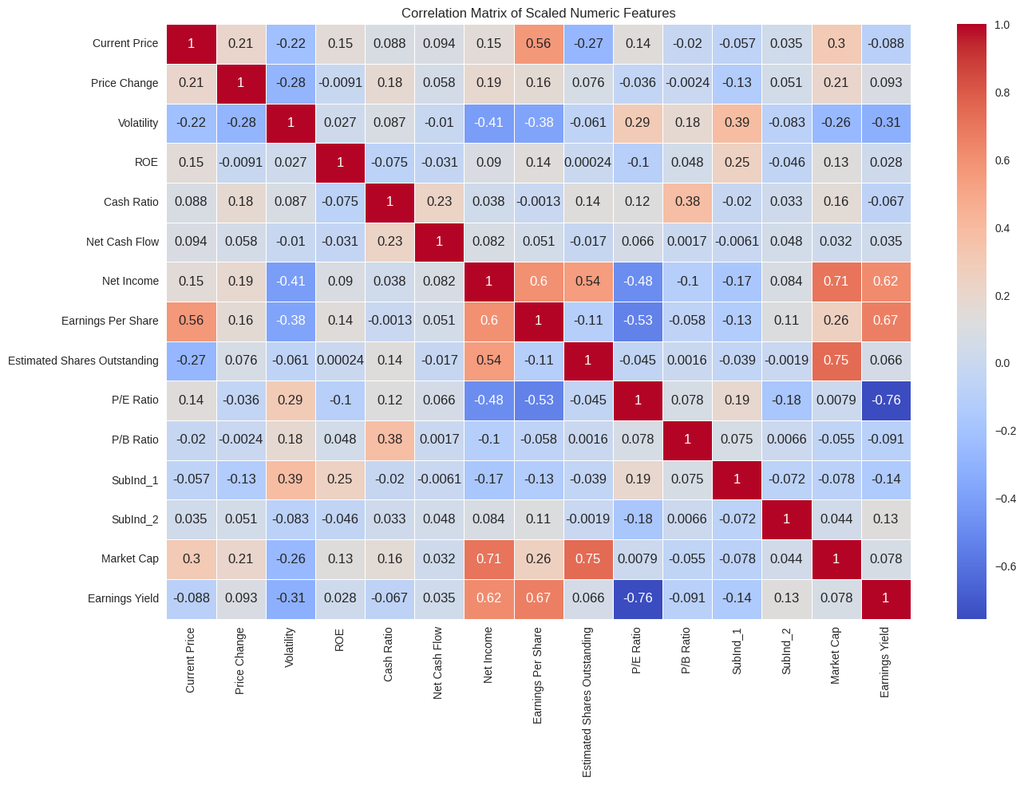

```
Dropped 0 highly correlated features.
Final dataset shape: (340, 26)
```

```python
# For testing purposes
data = df.copy()

#------------------------------------------------------#

# Drop 'Ticker Symbol' and 'Security' columns from the DataFrame - not useful
data = data.drop(columns=['Ticker Symbol', 'Security'])

#------------------------------------------------------#
# Convert remaining object-type columns to category dtype
categorical_cols = ['GICS Sector', 'GICS Sub Industry']
data[categorical_cols] = data[categorical_cols].astype('category')

#------------------------------------------------------#

# Encode GICS Sector normally, One-Hot encode GICS Sub Industry separately
sector_encoded = pd.get_dummies(data['GICS Sector'], prefix='Sector', drop_first=False)
subind_encoded = pd.get_dummies(data['GICS Sub Industry'], prefix='SubInd', drop_first=False)

#------------------------------------------------------#

# Apply PCA to Sub Industry Encoding
scaler_sub = StandardScaler()
subind_scaled = scaler_sub.fit_transform(subind_encoded)

pca = PCA(n_components=2)
subind_pca = pca.fit_transform(subind_scaled)
subind_pca_df = pd.DataFrame(subind_pca, columns=['SubInd_1', 'SubInd_2'])

# Add Sector Encoding, PCA SubIndustry, and original numerical features
data_combined = pd.concat([
    data.drop(columns=['GICS Sector', 'GICS Sub Industry']),
    sector_encoded,
    subind_pca_df
], axis=1)

print("Column names in data_combined:")
for col in data_combined.columns:
    print(col)

#------------------------------------------------------#

# Feature Engineering
data_combined['Market Cap'] = data_combined['Current Price'] * data_combined['Estimated Shares Outstanding']
data_combined['Earnings Yield'] = data_combined['Earnings Per Share'] / data_combined['Current Price']

print("\nAfter Feature Engineering:")
print(data_combined[['Market Cap', 'Earnings Yield']].head())

#------------------------------------------------------#

# Detect and Handle Outliers using IQR
numeric_cols = data_combined.select_dtypes(include=['float64', 'int64']).columns

for col in numeric_cols:
    Q1 = data_combined[col].quantile(0.25)
    Q3 = data_combined[col].quantile(0.75)
    IQR = Q3 - Q1
    lower = Q1 - 1.5 * IQR
    upper = Q3 + 1.5 * IQR
    data_combined[col] = np.where(data_combined[col] < lower, lower, data_combined[col])
    data_combined[col] = np.where(data_combined[col] > upper, upper, data_combined[col])

print("\nAfter Outlier Capping (min/max check):")
print(data_combined[numeric_cols].describe().T[['min', 'max']])

#------------------------------------------------------#

# Scale All Numeric Features
scaler_all = StandardScaler()
data_combined[numeric_cols] = scaler_all.fit_transform(data_combined[numeric_cols])

print("\nAfter Scaling:")
print(data_combined[numeric_cols].head())

#------------------------------------------------------#

# Correlation Matrix and Multicollinearity Check
corr_matrix = data_combined[numeric_cols].corr()

plt.figure(figsize=(14, 10))
sns.heatmap(corr_matrix, cmap='coolwarm', annot=True, linewidths=0.5)
plt.title('Correlation Matrix of Scaled Numeric Features')
plt.tight_layout()
plt.show()

# Identify highly correlated features
upper = corr_matrix.where(np.triu(np.ones(corr_matrix.shape), k=1).astype(bool))
to_drop = [column for column in upper.columns if any(upper[column] > 0.8)]

# Drop any too-correlated columns
data_reduced = data_combined.drop(columns=to_drop)

print(f"\nDropped {len(to_drop)} highly correlated features.")
print("Final dataset shape:", data_reduced.shape)
```